# Rumsey, Chapter 2: Organizing categorial data - charts and graphs. [Complete - Base graphics]

Maurizio Murino

5 February 2016

### Exercise 1 - 5/2/’16

Suppose 375 individuals are asked what type of vehicle they own: SUV, truck, ora car. See the following frequency table.

```r
e1 <- data.frame(category = integer(375))
e1$category <- rep(c("SUV","Truck","Car"), c(150,125,100))

# Frequency tables
xtabs(e1)
```

```
## category
##   Car   SUV Truck
##   100   150   125
```

**A. Make a relative frequency table of these results**

```r
round(prop.table(table(e1$category)), digits = 2)
```

```
##
##   Car   SUV Truck
##  0.27  0.40  0.33
```

**B. Make a pie chart of these results**

[figure not shown]

```r
pie(table(e1), labels = paste(c("SUV ","Truck ","Car "), round(prop.table(table(e1$category))*100, digits = 1), "%", sep = "") , main = "Vehicles - n: 375", col = rainbow(3))
legend("topleft", c("SUV","Truck","Car"), cex = 0.6, fill = rainbow(3))
```

C. Interpret the results

### Excercise 2 - 5/2/’16

For a month, a restaurant owner checks off whem a customer patronize his restaurant. He records the data for 1000 customers for one month.

```r
customers <- data.frame(category = integer(1000))
customers$category <- rep(c("Breakfast", "Lunch", "Dinner", "Other"), c(10*6.7, 10*22.2, 10*44.4, 10*26.7))
xtabs(customers)
```

```
## category
## Breakfast    Dinner     Lunch     Other
##        67       444       222       267
```

[figure not shown]

```r
pie(table(customers), labels = paste(c("Breakfast", "Lunch", "Dinner", "Other"), round(prop.table(table(customers$category))*100, digits = 2), "%" ), main = "Restaurant customers - n: 1000", col = rainbow(4))
legend("topright", c("Breakfast", "Lunch", "Dinner", "Other"), cex = 0.5, fill = rainbow(4))
```

**A. What does this information tell the restaurant owner?**

**B. What is the problem with the “other” category? How can this study improved in the future?**

### Excercise 3 - 7/2/16

A manager decides to categorize her e-mails into five groups: 1) highest, 2) medium, 3) low priority, 4) personal and 5) SPAM.

```r
e3 <- data.frame(400)
e3 <- rep( c("high", "medium", "low", "personal", "SPAM"), c(60, 120, 20, 50, 150))

# Frequency table
table(e3)
```

```
## e3
##     high      low   medium personal     SPAM
##       60       20      120       50      150
```

**A. Make a relative frequency table.**

```r
paste(prop.table(table(e3))*100, "%", sep = "")
```

```
## [1] "15%"   "5%"    "30%"   "12.5%" "37.5%"
```

**B Make a pie chart of this data.**

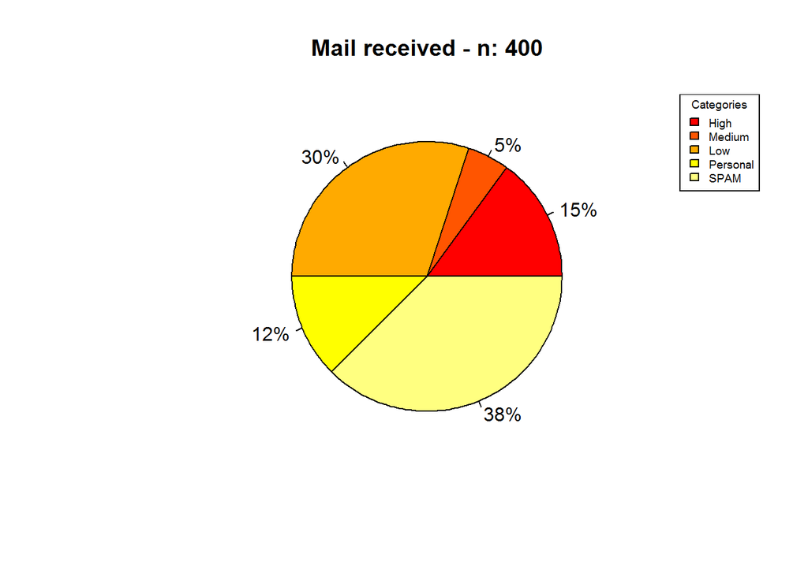

```r
# Does not work with Knitr.
# par(mar=c(5.1, 4.1, 4.1, 8.1), xpd=TRUE)

pie(table(e3), labels = paste(round(prop.table(table(e3))*100), "%", sep = ""), col = heat.colors(5), main = "Mail received - n: 400")

# With Knitr the legend is not visible, while there is no problem with the normal plot output.

#usr <- par("usr")*1.2; rect(usr[1], usr[3], usr[2], usr[4], lwd=2, col=NA)
legend("topright", legend = c("High", "Medium", "Low", "Personal", "SPAM"), fill = heat.colors(5), title = "Categories", cex = 0.6)
```

**C. Interpret the result**

Being able of immediately point SPAM can reprensent a relevant contribute to productivity, since they are are the most conspicuous category: 38% of 400.

### Excercise 4 - 10/2/16

Suppose a survey is conducted to see what tyoes od pets people own. The survey of 100 adults finds that 40 of the own a dog, 60 a cat, 20 a fish, 10 a rodent. Can this data be organized in a pie chart?

**Solution:** It cannot. Since each adult is allowed to possess more than one animal, they can be counted more than one time(40 + 60 + 20 + 10 = 130). Hence, the observed cases would become more than the sample (100). In this case, an histogram would be preferable.

```r
e8 <- data.frame(100)
e8 <- rep(c("dog", "cat", "fish", "rodent"), c(40, 60, 20, 10))
table(e8)
```

```
## e8
##    cat    dog   fish rodent
##     60     40     20     10
```

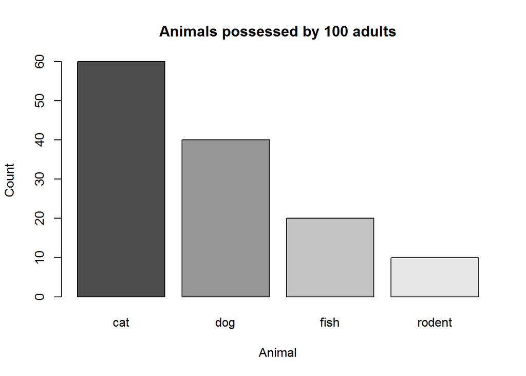

```r
barplot(table(e8), main = "Animals possessed by 100 adults", xlab = "Animal", ylab = "Count", col = gray.colors(4))
```

### Excercise 5 - 10/2/16

A road intersection is observed for four hours, observing if the drivers stop completely, roll through, ran the stop sign.

```r
e5 <- data.frame(rep(c("Complete stop", "Rolled through", "Ran the stop sign"), c(64.2, 35.2, 0.6)))
par("mar")
```

```
## [1] 5.1 4.1 4.1 2.1
```

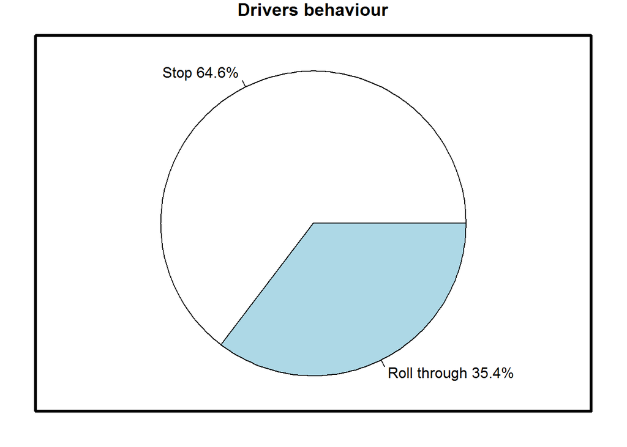

```r
par(mar=c(1,1,1,1))
pie(table(e5), main = "Drivers behaviour", labels = paste(c("Stop ", "Roll through ", "Ran the stop "), round(prop.table(table(e5))*100, 1), "%", sep = ""))
par(oma=c(2,2,2,2), mar=c(4.1, 4.1, 4.1, 4.1), xpd=TRUE) ; box("inner", col="black", lwd=3)
```

**A. Interpret the result as they appear on the chart**

**B. What information is missing from the pie chart?**

The dimension of the sample is missing.

**C. Does the missing information affect the interpretation of the results?**

Heavily. We cannot derive any information, since this plot could refer to almost any number of drivers.

**D. Should you make a generalization of all drivers based on this data?**

Not at all. Because of the reason stated in point B. we cannot even think any kind of inference.

### Excercise 6 - 27/2/16

A survey is conducted to determine whether 20 office employees of a certain company would prefer to work at home, if given the chance. Of the 10 women surveyed, 7 said yes, and three no. Of the 10 men, 8 said no, 2 said yes. Compare the result using two pie charts. Does gender seems to affect one’s preferences to work at home?

```r
e6 <- data.frame(gender = rep( c("man", "woman"), each=10))
e6$answer <- ifelse(e6$gender == "man", rep( c("yes", "no"), c(8, 2)), rep( c("yes", "no"), c(3, 7)))
```

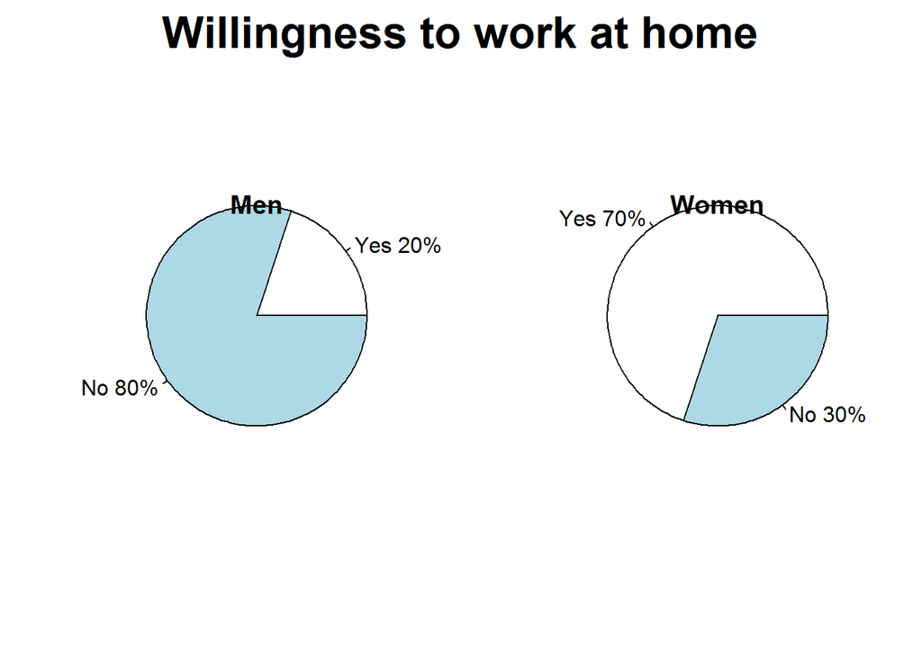

```r
par(mfrow = c(1, 2))

suppressWarnings(pie(table(e6$answer[e6$gender == "man"]), main = "Men", line = -4, labels = paste(c("Yes ", "No "), round(prop.table(table(e6$answer[e6$gender == "man"]))*100, 1), "%", sep = "")))

suppressWarnings(pie(table(e6$answer[e6$gender == "woman"]), main = "Women", line = -4, labels = paste(c("Yes ", "No "), round(prop.table(table(e6$answer[e6$gender == "woman"]))*100, 1), "%", sep = "")))

suppressWarnings(mtext("Willingness to work at home", side = 3, line = -2, outer = TRUE, cex=2,font=2))
```

Gender appears to be a relevant variable relatively to the willingness to work at home.

### Excercise 7 - 27/2/16

Give an example of categorical data that you cannot summarize correctly by using a pie chart.

**Solution:** Where the percentages does not sum up to 100. An observation or an individual could be part of more than one group.

### Excercise 8 - 27/2/16

Surfing non-work-related websites compromises employee productivity.

```r
e8 <- data.frame(employer = rep( c("no", "yes"), c(334, 666)))
e8$employee <- rep( c("no", "yes"), c(498, 502))
```

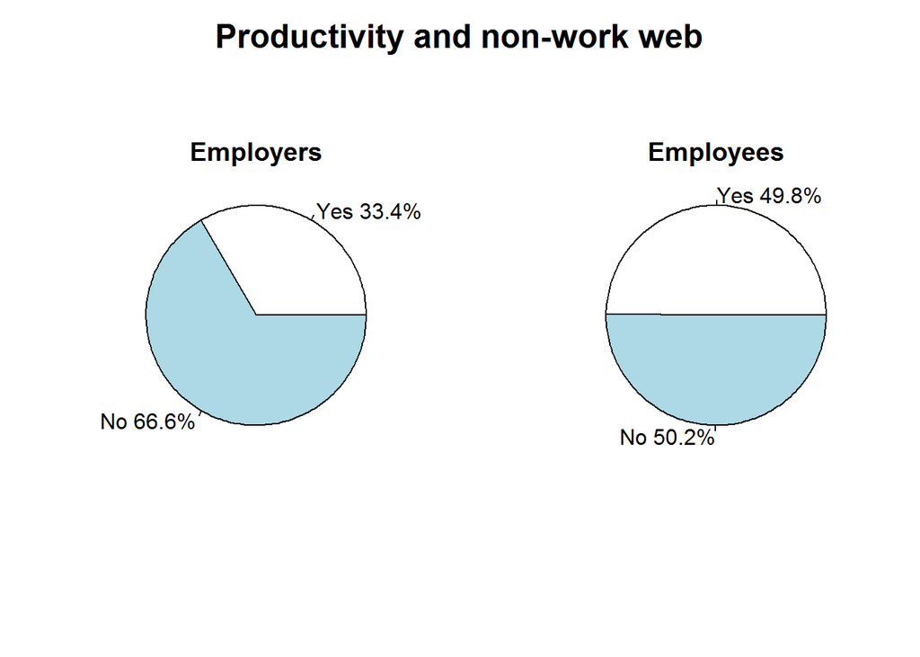

```r
par(mfrow = c(1, 2))

suppressWarnings(pie(table(e8$employer), main = "Employers", line = -2, labels = paste(c("Yes ", "No "), round(prop.table(table(e8$employer))*100, 1), "%", sep = "")))

suppressWarnings(pie(table(e8$employee), main = "Employees", line = -2, labels = paste(c("Yes ", "No "), round(prop.table(table(e8$employee))*100, 1), "%", sep = "")))

suppressWarnings(mtext("Productivity and non-work web", side = 3, line = -2, outer = TRUE, cex = 1.5, font = 2))
```

**A. Interpret these results**

**B. What important information is missing from pie chart?**

The dimension of the sample. (I created the data artificially with 1000 observation.)

### Excercise 9 - 27/2/16

Here is the frequency bar graph of 500 people between three categories (1: favor, 2: oppose, 3: neutral) about the possibility of smoking.

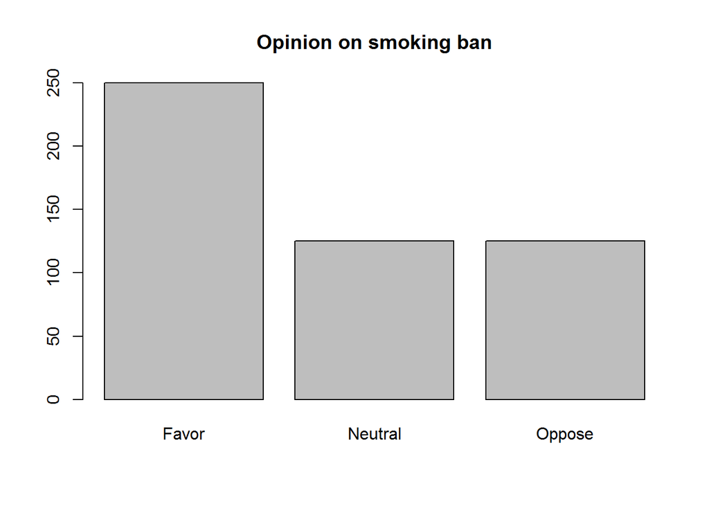

```r
e8 <- data.frame(opinion = rep(c("Favor", "Oppose", "Neutral"), c(250, 125, 125)))
barplot(table(e8), main = "Opinion on smoking ban")
```

**A. Make a relative frequency table of this data.**

```r
paste(prop.table(table(e8))*100, "%", sep = "")
```

```
## [1] "50%" "25%" "25%"
```

**B. Use the relative frequency table to make a bar graph of this data.**

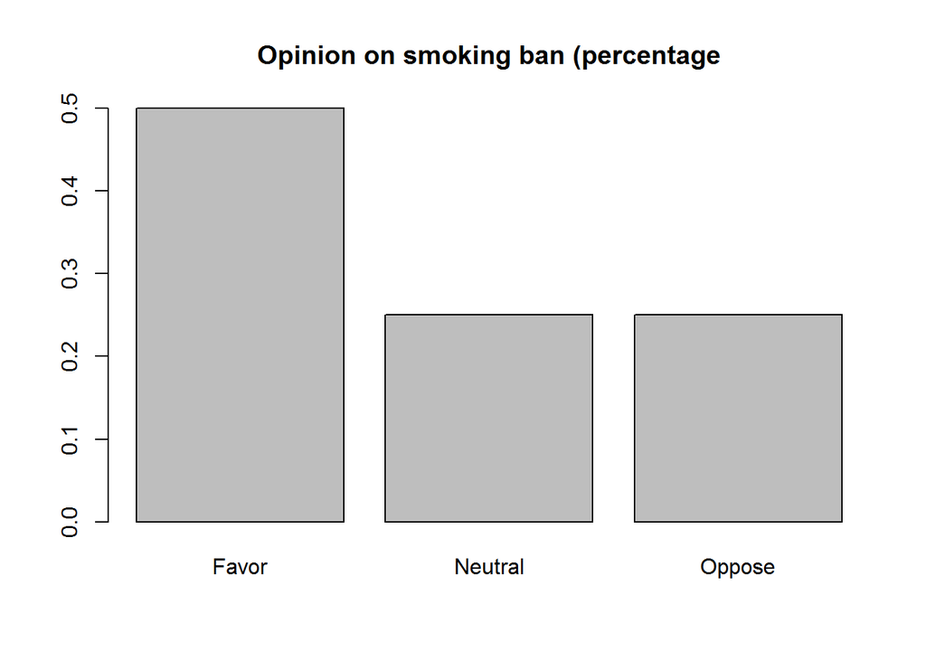

```r
barplot(prop.table(table(e8)), main = "Opinion on smoking ban (percentage")
```

**C. Interpret the result.**

The half of the sample favors the smoking ban. The same amount of of people oppose the ban and does not care about it.

### Excercise 10 - 27/2/16

A health club asks their customers to rate their service (very good, 1; good, 2; fair, 3; poor, 4). What percentages od the of the customers rated the services as good?

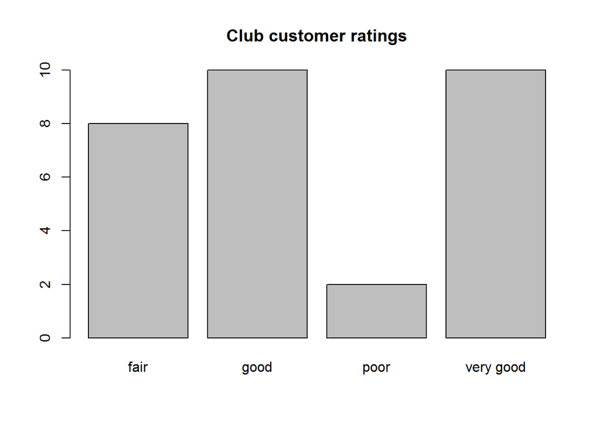

```r
e10 <- data.frame(rate = rep(c("very good", "good", "fair", "poor"), c(10, 10, 8, 2)))
barplot(table(e10), main = "Club customer ratings")
```

```r
paste(round(prop.table(table(e10)), 2)*100, "%", sep = "")
```

```
## [1] "27%" "33%" "7%"  "33%"
```

### Excercise 11 - 28/2/16

Do voters agree about the “Opinion X”? yes: 500; no: 550; dk: 250.

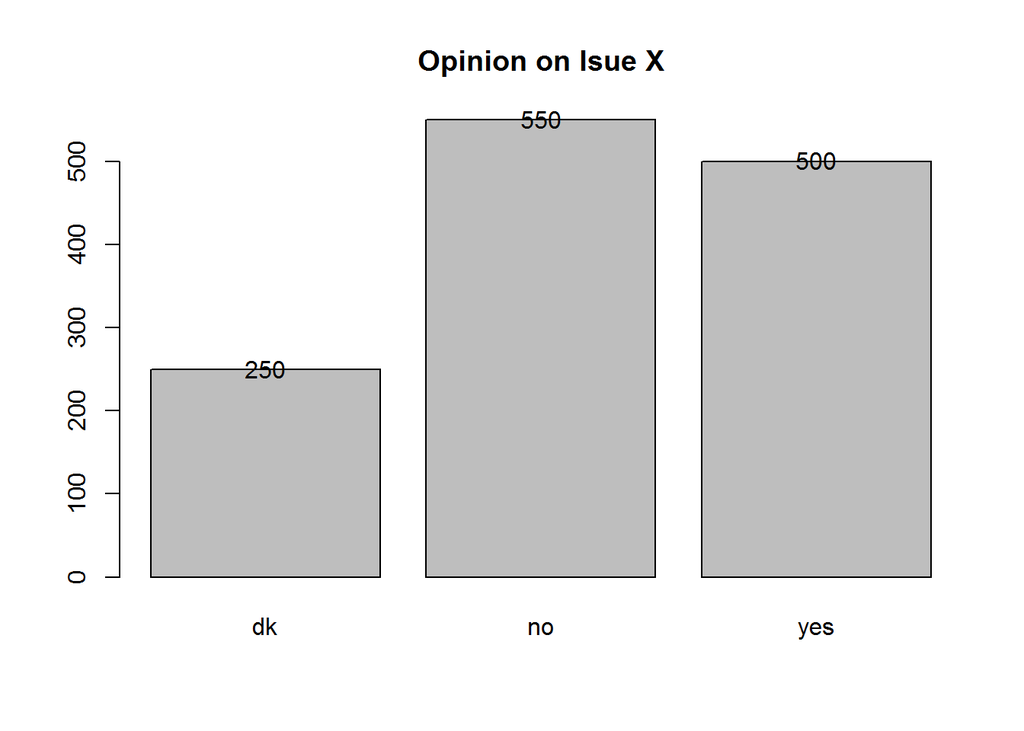

```r
e11 <- data.frame(opinion = rep(c("yes", "no", "dk"), c(500, 550, 250)))
a1 <- barplot(table(e11), main = "Opinion on Isue X")
text(y= table(e11) + 1, x= a1, labels=as.character(table(e11)), xpd=TRUE)
```

**A. Make the frequency table of these results (including the total number).**

```r
paste(round(prop.table(table(e11)), 2)*100, "%", sep = "")
```

```
## [1] "19%" "42%" "38%"
```

```r
table(e11)
```

```
## e11
##  dk  no yes
## 250 550 500
```

**B. Evaluate the graph as to whether or not it fairly represents the results.**

No, the original graph from the book clearly does tot represent the correct proportion between the categories.

### Excercise 12 - 28/2/16

What are the priority of 270 seniors, including whether or not buying a home.

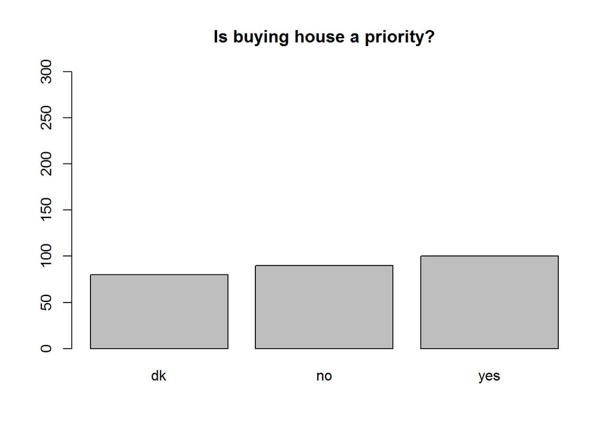

```r
e12 <- data.frame(answer = rep(c("yes", "no", "dk"), c(100, 90, 80)))
p12.1 <- barplot(table(e12), axes = F, ylim = c(0, 300), main = "Is buying house a priority?")
axis(2, c(0, 50, 100, 150, 200, 250, 300))
```

**A. The original bargraph is misleading: explain why.**

The bar graph does not have a scale capable of make the differences between categories frequencies.

**B. Make the new bar graph that more fairly presents the results.**

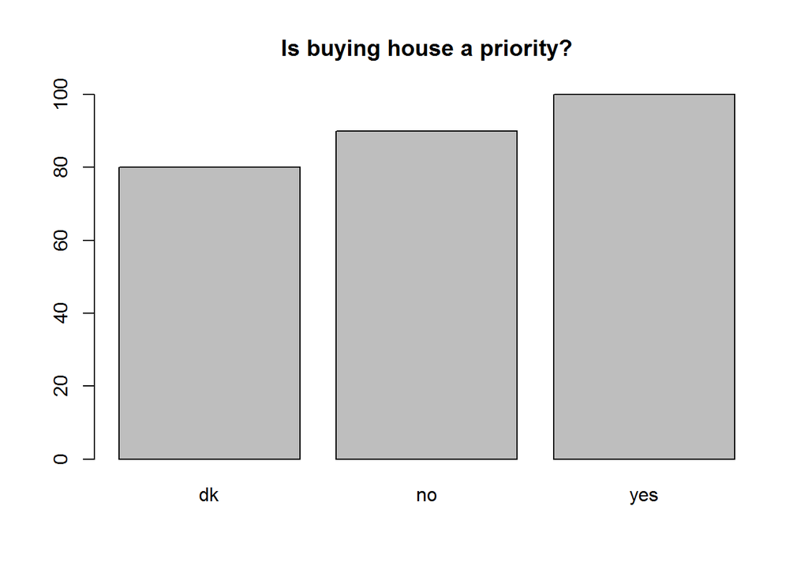

```r
p12.2 <- barplot(table(e12), ylim = c(0, 100), main = "Is buying house a priority?")
```

### Excercise 13 - 28/2/16

Are the customers males or females?

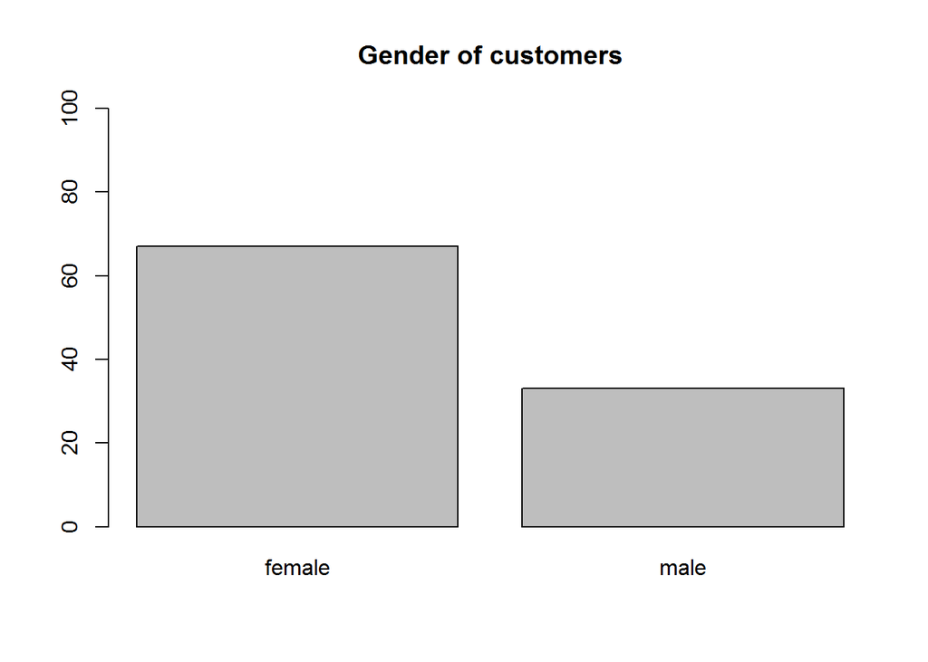

```r
e13 <- data.frame(gender = rep(c("male", "female"), c(330, 670)))
barplot(prop.table(table(e13))*100, ylim = c(0, 100), main = "Gender of customers")
```

**A. Interpret this result.**

The customers are roughly 67% females.

**B. Is the bar plot a fari and accurate representation of the data?**

Yes, it is ok since it represent the proportions between the two categories, even if a pie chart could be more adequate.

### Excercise 14 - 28/2/16

Sample of 20 employees. Do they prefer work from home?

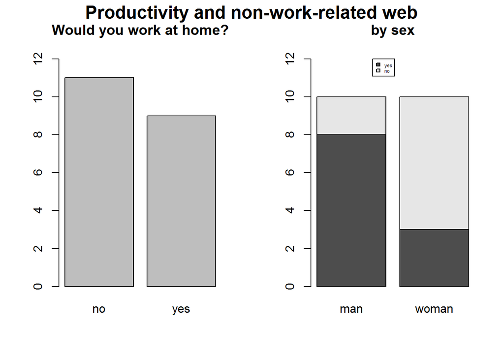

```r
e14 <- data.frame(gender = rep(c("man", "woman"), each = 10))
e14$answer <- ifelse(e14$gender == "man", rep(c("yes", "no"), c(2, 8)), rep(c("yes", "no"), c(7, 3)))

par(mfrow = c(1, 2))

barplot(table(e14$answer), main = "Would you work at home?", ylim = c(0, 12))

par(mar = c(5.1, 4.1, 4.1, 2))
par(xpd = TRUE)

barplot(table(e14$answer, e14$gender), main = "by sex", col = gray.colors(length(unique(e14$answer))), ylim = c(0, 12))

legend(1, 12, c("yes", "no"), cex = 0.4, fill = gray.colors(length(unique(e14$answer))))

mtext("Productivity and non-work-related web", side = 3, line = -1.5, outer = TRUE, cex = 1.5, font = 2)
```

**A. Interpret the result of each graph.**

**B. Discuss the added value in including gender in the second bra graph.**

It permits us a better understanding of the resut in graph 1. That is, a common filter policy could be differently satisfactory between men and women.